# TMS iTBS - nback RT analysis

2026-06-03

## Introduction

In this file, you find our results of research question 1 of the paper. We start this file with data processing (the same as all other files) and then delve into our main findings. Readers interested in verifying the main result in RQ1 should search for the string “Research Question 1”. ## Packages

```r
# import packages
library(lme4)     # mixed models
library(dplyr)    # dataframe manipulation
library(readr)    # reading in the data
library(emmeans)  # likelihood ratio testing
```

```r
library(purrr)    # for map()
library(lattice)  # for xyplot()
library(TAF)      # setting up output file directory structure during model fitting
library(moments)  # skewness for selecting between additive and multiplicative models of response times
library(effectsize) # for cohens d
#If you get an error, you likely need to install the packages using the "install.package('insert-package-name-here')" command
```

## Notebook configurable settings

make an overall output directory (model summaries, stats, etc. will all go here)

```r
# name the directories to read data from and write output to
input_version = ''
output_version = 'nback'
outputdir = sprintf("%s/../candidate-models/regression-models-%s",getwd(), output_version)
```

```r
mkdir(outputdir)
```

## Loading Data

In this step, we load our data. We also filter out data points in which response time is null, i.e., no response to the question given from the participant.

We expect 6720 rows. Each row is an item level data point – an instance where a participant answered a stimulus question.

```r
input_file = sprintf("%s/../nback-full-data.csv", getwd())
raw_data <- read.csv(input_file)

# Keep rows where duration_seconds is NOT NA
raw_data <- raw_data[!is.na(raw_data$duration), ]
raw_data$correct_num <- ifelse(raw_data$correct_answer == "True", 1, 0)


nrow(raw_data)
```

```
## [1] 6720
```

## Filtering and Data Quality

In this procedure, we take steps to support data quality.

### Removing irrelevant participants

In this step, we remove the data of participants we knew to be pilots as well as one participant who, upon researcher inspection, did not pass any programming tasks.

After this step, we expect 6360 rows – an instance where a participant answered a stimulus question.

```r
participants_to_remove <- c(#Pilots
                            "Sarah", "pilot", "K9TX",

                            #Participant who failed all programming tasks
                            "Y5DG"
                            )

data <- subset(raw_data, !(participant_id %in% participants_to_remove))

nrow(data)
```

```
## [1] 6360
```

### Filter data based on manual annotation

In this step, we remove rows (i.e., instances in which person X answered question Y) corresponding to incidents in which the laboratory notebook maintained by the experimenter indicated non-compliance with our protocol or other externalities that invalidate the observation. See Section ‘Analysis Methodology’ of the paper text for more information.

However, for all instances where N-back was done, the researcher reports no issues. Thus, we do not do this step

```r
# Nothing happens :) ; see note above
```

## Selecting Data for Analysis

In this step, we primarily care about analyzing response times in which participants got the trial correct; correct only response times. Thus, we select those trials and we expect 4,757 rows.

```r
data <- data[data$correct_answer == "True", ]

nrow(data)
```

```
## [1] 4757
```

### Consistency Check: Mean reaction time (reported in paper)

```r
mean_value <- mean((data$response_time))
print(mean_value)
```

```
## [1] 0.8539478
```

We calculate mean response times per tms condition. “WM” represents the treatment condition and “CM” represents the control condition in our data.

```r
tmsW <- data[(data$tms_type == "WM"), ]

mean_value <- mean((tmsW$response_time))
print(mean_value)
```

```
## [1] 0.8650301
```

```r
tmsC <- data[(data$tms_type == "CM"), ]

mean_value <- mean((tmsC$response_time))
print(mean_value)
```

```
## [1] 0.8452878
```

We also look at the distribution and find that it is normally distributed

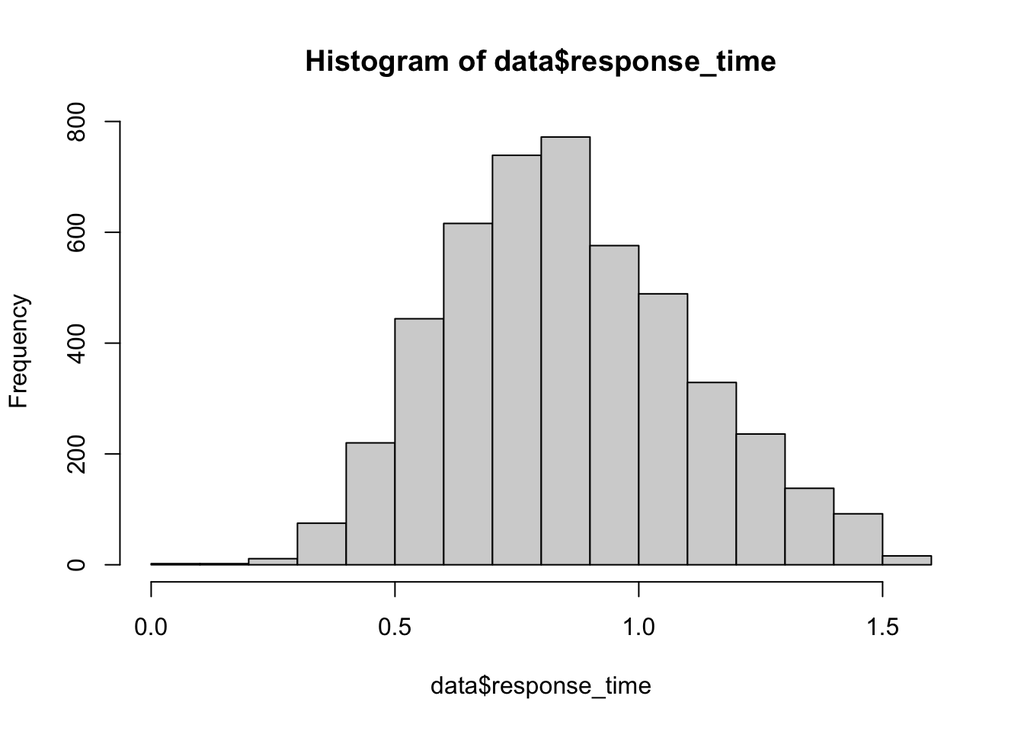

```r
hist(data$response_time)
```

## TMS Response Time (Research Question 1)

For interpretability of our results, we favor “simpler” statistics if possible (see Analysis Methodology: Section V.C) We begin with the Welch’s TTest.

```r
treatment = data[data$tms_type == 'WM',]
control = data[data$tms_type == 'CM',]


t.test(treatment$response_time, control$response_time)  #Welch's ttest
```

```
##
##  Welch Two Sample t-test
##
## data:  treatment$response_time and control$response_time
## t = 2.7048, df = 4668.1, p-value = 0.006859
## alternative hypothesis: true difference in means is not equal to 0
## 95 percent confidence interval:
##  0.005432877 0.034051710
## sample estimates:
## mean of x mean of y
## 0.8650301 0.8452878
```

```r
cohens_d(treatment$response_time, control$response_time, pooled_sd = FALSE) #Cohen's d
```

```
## Cohen's d |       95% CI
## ------------------------
## 0.08      | [0.02, 0.14]
##
## - Estimated using un-pooled SD.
```